# IgG Transplacental

Usman

2023-10-20

## 0.1 R Markdown of my paper on IgG transplacental transfer from mother to her foetus

## 0.2 **Introduction**

## 0.3 **Abstract**

### 0.3.1 **Introduction**

Immunoglobulin G (IgG) forms the backbone of the circulating adaptive immune system. Efficient transplacental transfer of maternal adaptive immunity to neonates is crucial for early-life protection against infectious diseases, emphasizing the significance of understanding IgG subclass concentrations and transfer efficiency.

### 0.3.2 **Methods**:

Paired blood samples from 41 mother-infant pairs were collected to evaluate total and subclass IgG levels. Maternal demographic and clinical information was also obtained.

### 0.3.3 **Results**:

Maternal and cord blood showed similar IgG subclass profiles, with a notable gradient of transfer efficiency for IgG subclasses, particularly IgG2 and IgG3, and negative associations between maternal IgG concentrations and transfer ratios.

### 0.3.4 **Conclusions**:

Our findings suggest reduced transplacental transfer of maternal IgG antibodies, emphasizing the role of IgG2 concentration in maternal BMI association and the potential relationship of increased IgG3 levels with antigen-specific response. These results offer valuable insights into the population-specific dynamics of transplacental IgG transfer and warrant further biochemical and physiological investigations.

```r
library(readxl)
Gestation <- read_excel("~/M.Sc. RAW DATA.xlsx",
                        sheet = "Sheet1")
Gestation
```

```
## # A tibble: 42 × 75
##    StujectID   Age `Weight (kg)` `Height (m)` `BMI (Kg/M^2)` Tribe
##        <dbl> <dbl>         <dbl>        <dbl>          <dbl> <chr>
##  1         1    30            80         1.71           27.4 Hausa
##  2         2    29            62         1.58           24.8 Bajju
##  3         3    18            54         1.58           21.6 Hausa
##  4         4    22            59         1.62           22.5 Yoruba
##  5         5    40            89         1.69           31.2 Hausa
##  6         6    42            85         1.66           30.8 Yoruba
##  7         7    33            66         1.69           23.1 Urobo
##  8         8    25            65         1.78           20.5 Hausa
##  9         9    33            78         1.55           32.5 Kilba
## 10        10    26            75         1.52           32.5 Igala
## # ℹ 32 more rows
## # ℹ 69 more variables: `1. How many times do you eat` <dbl>,
## #   `2. class of food` <chr>, `3. physical exercise` <chr>,
## #   `4. if yes, detail` <chr>, `5. Smoke?` <chr>, `6. If yes, packs?` <dbl>,
## #   `7. ethanol?` <chr>, `8. If yes, grams/units?` <dbl>,
## #   `9. If yes, detail?` <chr>, `10. Drugs?` <chr>,
## #   `11. If yes, specify.` <chr>, `1. Pregnancies no.` <dbl>, …
```

## 0.4 Including Plots

```r
Maternal<-Gestation[-42,]%>%select(c(51:55))%>%
  rename(IgG1="M-IgG1",IgG2="M-IgG2",IgG3="M-IgG3",IgG4="M-IgG4",Total="M-Total")%>%
  pivot_longer(cols = c(IgG1,IgG2,IgG3,IgG4,Total),names_to = "Maternal",values_to = "m_IgG")

Cord<-Gestation[-42,]%>%select(c(56:60))%>%
  rename(IgG1="C-IgG1",IgG2="C-IgG2",IgG3="C-IgG3",IgG4="C-IgG4",Total="C-Total")%>%
  pivot_longer(cols = c(IgG1,IgG2,IgG3,IgG4,Total),names_to = "Cord",values_to = "c_IgG")

Maternal$group<- "Maternal"
Cord$group<-"Cord"
fetal<-rename(Cord,Maternal=Cord,m_IgG="c_IgG")

maternalfetal<-rbind(Maternal,fetal)
maternalfetal
```

```
## # A tibble: 410 × 3
##    Maternal m_IgG group
##    <chr>    <dbl> <chr>
##  1 IgG1      3.13 Maternal
##  2 IgG2      1.08 Maternal
##  3 IgG3      0.78 Maternal
##  4 IgG4      1.78 Maternal
##  5 Total     6.77 Maternal
##  6 IgG1      4.33 Maternal
##  7 IgG2      0.78 Maternal
##  8 IgG3      0.46 Maternal
##  9 IgG4      0.89 Maternal
## 10 Total     6.46 Maternal
## # ℹ 400 more rows
```

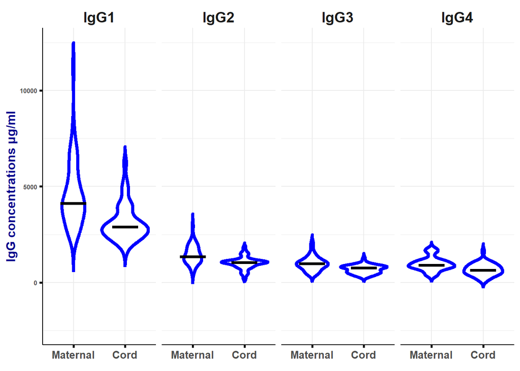

```r
ggplot(data=filter(maternalfetal,Maternal !="Total"),aes(x=group,y=m_IgG*1000))+
  geom_violin(trim = FALSE,col="blue",size=1.5)+
  facet_wrap(~Maternal,nrow=1)+
  stat_summary(fun.y = median, fun.ymin = median, fun.ymax = median,
               geom = "crossbar", width = 0.5)+
  theme_minimal()+scale_x_discrete(limits=c("Maternal","Cord"))+
  theme(strip.text=element_text(size = 13.7,face = "bold"))+
  theme(axis.title.y=element_text(colour="darkblue",size=12,face = "bold"),
        axis.line = element_line(colour="black"),
        axis.text.x = element_text(size = 10),
        axis.ticks = element_line(size = 1))+
  labs(x=element_blank(),y="IgG concentrations μg/ml")+
  theme(axis.text=element_text(size = 6,face = "bold"))+
  ylim(-2500,12500)
```

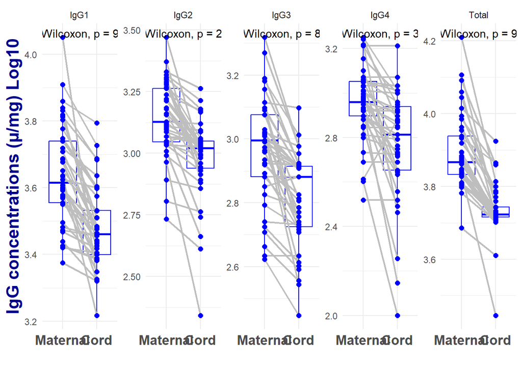

```r
library(ggpubr)
ggpaired(
  maternalfetal,x="group",y="log10(m_IgG*1000)", line.size = 0.8,
  line.color = "gray",point.size=2,width=0.8,color = "blue")+
  facet_wrap(~Maternal,nrow = 1,scales = "free")+
  scale_color_manual(name="",values = c("blue","black"))+
  theme_minimal()+stat_compare_means(paired = TRUE)+
  labs(x="",y="IgG concentrations (µ/mg) Log10",front="bold")+
  theme(legend.position = "none",axis.title = element_text(face ="bold",
  color = "darkblue",size = 17),axis.text.x = element_text(face = "bold",
  size = 13))+scale_x_discrete(label = c("Maternal"="Maternal","Cord"="Cord"))
```

Transplacental transfer ratio

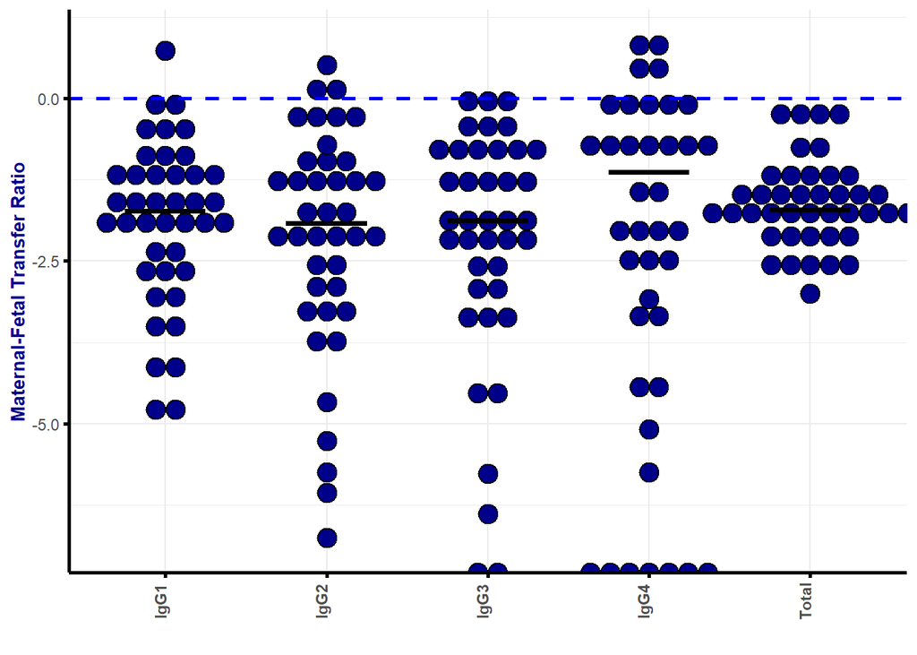

```r
maternalfetaltrans<-cbind(Maternal,Cord)%>%
  select(Maternal,m_IgG,Cord,c_IgG)%>%
  mutate(m_IgG=m_IgG*1000,c_IgG=c_IgG*1000)%>%
  mutate(ratio=log(m_IgG/c_IgG))%>%mutate(log2trans=log2(ratio))%>%
  ggplot(aes(Maternal,log2trans))+
  geom_dotplot(binaxis = "y", binwidth = 0.3, stackdir = "center",
               fill="darkblue")+stat_summary(fun.y = median, fun.ymin = median,
              fun.ymax = median,geom = "crossbar", width = 0.5)+theme_minimal()+
  geom_hline(yintercept = 0,lty="dashed",size=1,color="blue")+
  theme(axis.title.y=element_text(colour="darkblue",size=10,face = "bold"),
        axis.line = element_line(colour="black",size = 1),axis.ticks = element_line(size = 1),
        axis.text.x = element_text(angle = 90,face="bold",vjust = 0.02))+xlab("")+
        ylab("Maternal-Fetal Transfer Ratio")
maternalfetaltrans
```

```r
maternalfetaltrans_gest<-maternalfetaltrans<-cbind(Maternal,Cord)%>%
  select(Maternal,m_IgG,Cord,c_IgG)%>%
  mutate(m_IgG=m_IgG*1000,c_IgG=c_IgG*1000)%>%
  mutate(ratio=log(m_IgG/c_IgG))%>%mutate(log2trans=log2(ratio))
maternalfetaltrans_gest
```

```
##     Maternal m_IgG  Cord c_IgG        ratio   log2trans
## 1       IgG1  3130  IgG1  2440  0.249034965 -2.00557978
## 2       IgG2  1080  IgG2  1060  0.018692133 -5.74142498
## 3       IgG3   780  IgG3   520  0.405465108 -1.30235032
## 4       IgG4  1780  IgG4  1030  0.547054562 -0.87024336
## 5      Total  6770 Total  5050  0.293112844 -1.77047191
## 6       IgG1  4330  IgG1  3390  0.244737621 -2.03069221
## 7       IgG2   780  IgG2   720  0.080042708 -3.64308622
## 8       IgG3   460  IgG3   360  0.245122458 -2.02842543
## 9       IgG4   890  IgG4   740  0.184571277 -2.43775004
## 10     Total  6460 Total  5210  0.215049462 -2.21725957
## 11      IgG1  2370  IgG1  2090  0.125725889 -2.99164634
## 12      IgG2   980  IgG2   760  0.254234138 -1.97577033
## 13      IgG3   510  IgG3   390  0.268263987 -1.89827470
## 14      IgG4   990  IgG4   840  0.164303051 -2.60556882
```

[output cut: 191 more lines]

```r
library(rstatix)
#Maternal fetal transfer ratio relative to WHO categorized gestational age

gestAge<-Gestation[-42,]%>%select(c(51:55,73))%>%
  rename(IgG1="M-IgG1",IgG2="M-IgG2",IgG3="M-IgG3",IgG4="M-IgG4",
         Total="M-Total")%>%pivot_longer(cols = c(IgG1,IgG2,IgG3,IgG4,Total),
          names_to = "Maternal",values_to = "m_IgG")
gestAge
```

```
## # A tibble: 205 × 3
##    GestAe Maternal m_IgG
##    <chr>  <chr>    <dbl>
##  1 41-41  IgG1      3.13
##  2 41-41  IgG2      1.08
##  3 41-41  IgG3      0.78
##  4 41-41  IgG4      1.78
##  5 41-41  Total     6.77
##  6 39-40  IgG1      4.33
##  7 39-40  IgG2      0.78
##  8 39-40  IgG3      0.46
##  9 39-40  IgG4      0.89
## 10 39-40  Total     6.46
## # ℹ 195 more rows
```

```r
maternalfetaltrans_gest$GestAge<-gestAge$GestAe
maternalfetaltrans_gest
```

```
##     Maternal m_IgG  Cord c_IgG        ratio   log2trans GestAge
## 1       IgG1  3130  IgG1  2440  0.249034965 -2.00557978   41-41
## 2       IgG2  1080  IgG2  1060  0.018692133 -5.74142498   41-41
## 3       IgG3   780  IgG3   520  0.405465108 -1.30235032   41-41
## 4       IgG4  1780  IgG4  1030  0.547054562 -0.87024336   41-41
## 5      Total  6770 Total  5050  0.293112844 -1.77047191   41-41
## 6       IgG1  4330  IgG1  3390  0.244737621 -2.03069221   39-40
## 7       IgG2   780  IgG2   720  0.080042708 -3.64308622   39-40
## 8       IgG3   460  IgG3   360  0.245122458 -2.02842543   39-40
## 9       IgG4   890  IgG4   740  0.184571277 -2.43775004   39-40
## 10     Total  6460 Total  5210  0.215049462 -2.21725957   39-40
## 11      IgG1  2370  IgG1  2090  0.125725889 -2.99164634   37-38
## 12      IgG2   980  IgG2   760  0.254234138 -1.97577033   37-38
## 13      IgG3   510  IgG3   390  0.268263987 -1.89827470   37-38
## 14      IgG4   990  IgG4   840  0.164303051 -2.60556882   37-38
```

[output cut: 191 more lines]

```r
# using the function "labels+" in factor function
a<-expression(bold(""<="36w"))
b<-expression(bold(37^"0/7"*"w-"*38^"0/7"*w))
c<-expression(bold(39^"0/7"*"w-"*40^"0/7"*"w"))
d<-expression(bold(41^"0/7"*"w-"*41^"0/7"*"w"))
e<-expression(bold("">"42w"))

#pairwise comparison using "library(rstatix)"
pwc <- maternalfetaltrans_gest %>%
  group_by(GestAge)%>%
  dunn_test(ratio~Maternal,p.adjust.method = "none")
pwc <- pwc %>% add_xy_position(x = "Maternal")
pwc
```

```
## # A tibble: 50 × 14
##    GestAge .y.   group1 group2    n1    n2 statistic     p p.adj p.adj.signif
##    <chr>   <chr> <chr>  <chr>  <int> <int>     <dbl> <dbl> <dbl> <chr>
##  1 37-38   ratio IgG1   IgG2      12    12    0.175  0.861 0.861 ns
##  2 37-38   ratio IgG1   IgG3      12    12   -0.830  0.407 0.407 ns
##  3 37-38   ratio IgG1   IgG4      12    12    0.281  0.779 0.779 ns
##  4 37-38   ratio IgG1   Total     12    12    0.257  0.797 0.797 ns
##  5 37-38   ratio IgG2   IgG3      12    12   -1.01   0.315 0.315 ns
##  6 37-38   ratio IgG2   IgG4      12    12    0.105  0.916 0.916 ns
##  7 37-38   ratio IgG2   Total     12    12    0.0818 0.935 0.935 ns
##  8 37-38   ratio IgG3   IgG4      12    12    1.11   0.267 0.267 ns
##  9 37-38   ratio IgG3   Total     12    12    1.09   0.277 0.277 ns
## 10 37-38   ratio IgG4   Total     12    12   -0.0234 0.981 0.981 ns
## # ℹ 40 more rows
## # ℹ 4 more variables: y.position <dbl>, groups <named list>, xmin <dbl>,
## #   xmax <dbl>
```

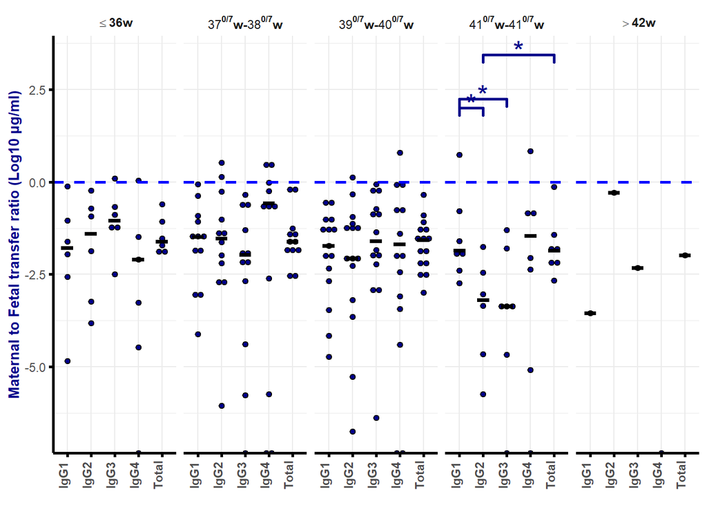

```r
mf_ratio_gestage<-maternalfetaltrans_gest%>%
  mutate(GestAge=recode(GestAge,"<42"=">42"))%>%
  ggplot(aes(Maternal,log2trans))+geom_dotplot(binaxis = "y", binwidth = 0.15,
  stackdir = "center",fill="darkblue")+facet_wrap(~factor(GestAge,
  levels=c("<36","37-38","39-40","41-41",">42"),labels=c(a,b,c,d,e)),
  labeller = label_parsed,nrow = 1)+stat_summary(fun.y = median,
  fun.ymin = median, fun.ymax = median,geom = "crossbar", width = 0.5)+
  theme_minimal()+geom_hline(yintercept = 0,lty="dashed",size=1,color="blue")+
  theme(axis.title.y=element_text("Maternal-Fetal Transfer Ratio",colour="darkblue",
  size=10,face = "bold"),axis.line = element_line(colour="black",size = 1),
  axis.ticks = element_line(size = 1),axis.text.x = element_text(angle = 90,
  face="bold",vjust = 0.02))+stat_pvalue_manual(pwc, tip.length = 0.02,
  hide.ns = TRUE,bracket.size = 1,size=7,label = "p.adj.signif",color="darkblue" )+
  labs(x=element_blank(),y="Maternal to Fetal transfer ratio (Log10 μg/ml)")
mf_ratio_gestage
```

```r
pwc1 <- maternalfetaltrans_gest %>%
  group_by(Maternal)%>%
  dunn_test(ratio~GestAge,p.adjust.method = "none")
pwc1 <- pwc1 %>% add_xy_position(x = "GestAge")
pwc1
```

```
## # A tibble: 50 × 14
##    Maternal .y.   group1 group2    n1    n2 statistic     p p.adj p.adj.signif
##    <chr>    <chr> <chr>  <chr>  <int> <int>     <dbl> <dbl> <dbl> <chr>
##  1 IgG1     ratio <36    <42        6     1   -1.19   0.236 0.236 ns
##  2 IgG1     ratio <36    37-38      6    12    0.417  0.676 0.676 ns
##  3 IgG1     ratio <36    39-40      6    15    0.0115 0.991 0.991 ns
##  4 IgG1     ratio <36    41-41      6     7    0.250  0.803 0.803 ns
##  5 IgG1     ratio <42    37-38      1    12    1.43   0.153 0.153 ns
##  6 IgG1     ratio <42    39-40      1    15    1.24   0.213 0.213 ns
##  7 IgG1     ratio <42    41-41      1     7    1.33   0.184 0.184 ns
##  8 IgG1     ratio 37-38  39-40     12    15   -0.524  0.600 0.600 ns
##  9 IgG1     ratio 37-38  41-41     12     7   -0.146  0.884 0.884 ns
## 10 IgG1     ratio 39-40  41-41     15     7    0.292  0.770 0.770 ns
## # ℹ 40 more rows
## # ℹ 4 more variables: y.position <dbl>, groups <named list>, xmin <dbl>,
## #   xmax <dbl>
```

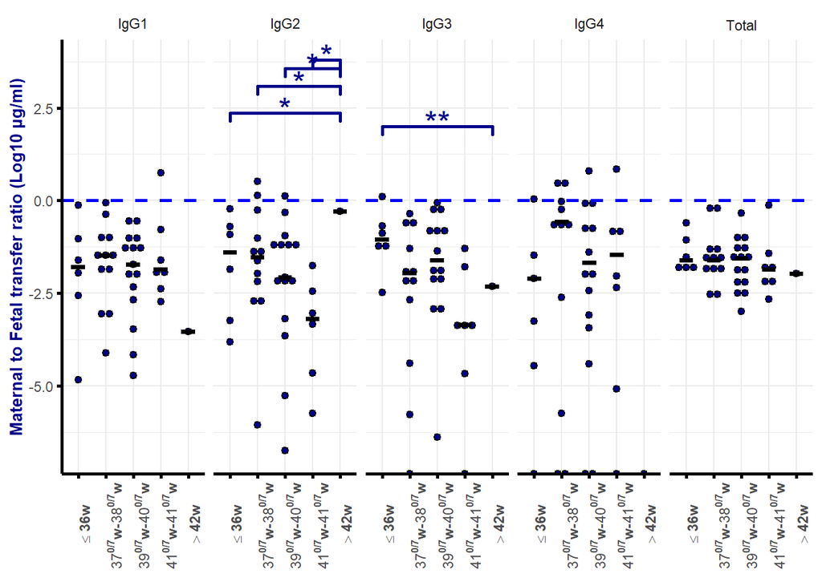

```r
mf_ratio_IgG<-maternalfetaltrans_gest%>%
  mutate(GestAge=recode(GestAge,"<42"=">42"))%>%
  ggplot(aes(factor(GestAge,levels=c("<36","37-38","39-40","41-41",">42"),
  labels=c(a,b,c,d,e)),log2trans),labeller=label_parsed)+
  geom_dotplot(binaxis = "y", binwidth = 0.2, stackdir = "center",fill="darkblue")+
  facet_wrap(~Maternal,nrow = 1,labeller=label_parsed)+stat_summary(fun.y = median,
  fun.ymin = median, fun.ymax = median,geom = "crossbar", width = 0.5)+
  theme_minimal()+geom_hline(yintercept = 0,lty="dashed",size=1,color="blue")+
  theme(axis.title.y=element_text(colour="darkblue",size=10,face = "bold"),
  axis.line = element_line(colour="black",size = 1),
  axis.ticks = element_line(size = 1),axis.text.x = element_text(angle = 90,
  face="bold"))+scale_x_discrete(labels=c(a,b,c,d,e))+stat_pvalue_manual(pwc1,
  tip.length = 0.02, hide.ns = TRUE,bracket.size = 1,size=7,
  label = "p.adj.signif",color="darkblue" )+labs(x=element_blank(),
  y="Maternal to Fetal transfer ratio (Log10 μg/ml)")
mf_ratio_IgG
```

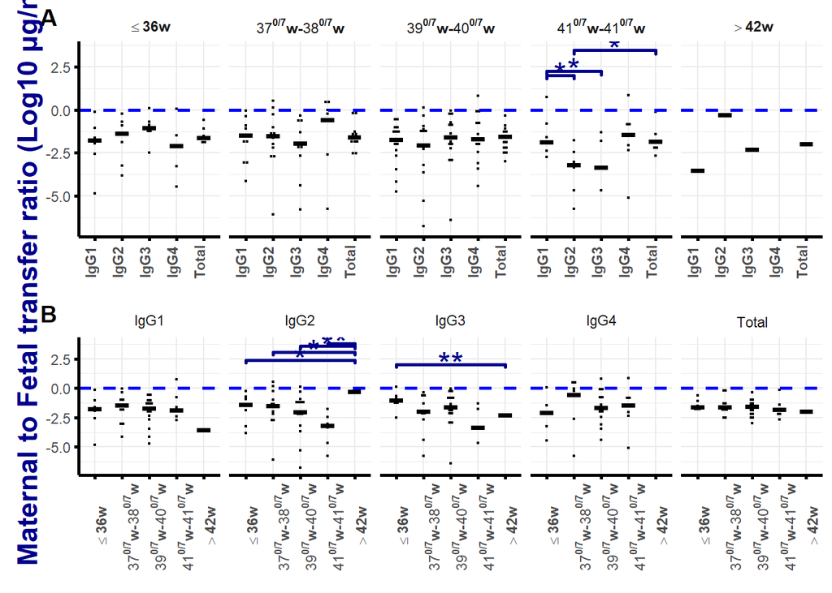

```r
A<-mf_ratio_gestage+rremove("ylab")
B<-mf_ratio_IgG+rremove("ylab")
figure <- ggarrange(
  A,B,labels = c( "A","B"),nrow = 2,
  common.legend = TRUE, legend = "none")

annotate_figure(figure,
                left = text_grob(
                  "Maternal to Fetal transfer ratio (Log10 μg/ml)",
                  rot = 90, vjust = 1,color="darkblue",size = 17,
                  face = "bold",hjust = 0.45)
                )
```